# DIA LFQ Benchmark Analysis

Jackson Gabriel Miyamoto

2026-10-31

# Overview

This workflow evaluates quantitative performance of DIA proteomics data using a mixed-species benchmark containing Human, *Saccharomyces cerevisiae* (Yeast), and *Escherichia coli* proteins with predefined abundance ratios between experimental conditions A and B.

The analysis evaluates:

- protein-level quantitative precision;
- accuracy of measured fold changes;
- deviation from theoretical abundance ratios;
- abundance-dependent quantitative performance; and
- species-specific quantitative behavior.

The workflow operates on the protein-group quantitative matrix generated by DIA-NN (`report.pg_matrix.tsv`).

DIA-NN protein-group matrices contain normalised protein-group quantities. Protein groups are therefore treated as the primary quantitative entities in this analysis.

# Methods

## Experimental design

The expected species-specific abundance ratios are:

| Species | Condition A | Condition B | Expected B/A | Expected log2(B/A) |
| --- | --- | --- | --- | --- |
| Human | 65 | 65 | 1.00 | 0 |
| Yeast | 15 | 30 | 2.00 | 1 |
| *E. coli* | 20 | 5 | 0.25 | -2 |

All fold changes are calculated as:

$$\log_2(B/A) = \log_2\left(\frac{\bar{B}}{\bar{A}}\right)$$

where $\bar{A}$ and $\bar{B}$ are the arithmetic mean protein-group quantities across the three technical/biological replicates in conditions A and B, respectively.

```r
library(tidyverse)
```

```r
library(ggplot2)
library(ggridges)
```

# Input Data

```r
report <- read.delim("report.pg_matrix.tsv", check.names = FALSE, stringsAsFactors = FALSE)

dim(report)
```

```
## [1] 11221    12
```

# Remove Contaminants

```r
df <- report %>%
  filter(!grepl("crap", Protein.Group, ignore.case = TRUE))

cat("Protein groups removed as contaminants:", nrow(report) - nrow(df), "\n")
```

```
## Protein groups removed as contaminants: 30
```

```r
cat("Proteins after contaminant removal:", nrow(df), "\n")
```

```
## Proteins after contaminant removal: 11191
```

# Remove Ambiguous Species Assignments

Proteins assigned to more than one species are excluded.

```r
mixed_species <- df %>%
  filter(
    grepl("_HUMAN", Protein.Names) +
    grepl("_YEAST", Protein.Names) +
    grepl("_ECOLI", Protein.Names) > 1)

cat("Ambiguous identifications:", nrow(mixed_species), "\n")
```

```
## Ambiguous identifications: 1
```

```r
df <- df %>%
  filter(
      !(grepl("_HUMAN", Protein.Names) +
      grepl("_YEAST", Protein.Names) +
      grepl("_ECOLI", Protein.Names) > 1))
```

# Species Annotation

```r
df <- df %>%
  mutate(species = case_when(
      grepl("_HUMAN", Protein.Names, ignore.case = TRUE) ~ "HUMAN",
      grepl("_YEAST", Protein.Names, ignore.case = TRUE) ~ "YEAST",
      grepl("_ECOLI", Protein.Names, ignore.case = TRUE) ~ "ECOLI",
      TRUE ~ NA_character_)) %>%
  filter(!is.na(species))

table(df$species)
```

```
##
## ECOLI HUMAN YEAST
##  1768  8103  1319
```

# Experimental Design

```r
sampleComposition <- tibble(
  species = c("HUMAN", "YEAST", "ECOLI"),
  A = c(65, 15, 20),
  B = c(65, 30, 5)) %>%
  mutate(expected_logFC = log2(B / A))

sampleComposition
```

```
## # A tibble: 3 × 4
##   species     A     B expected_logFC
##   <chr>   <dbl> <dbl>          <dbl>
## 1 HUMAN      65    65              0
## 2 YEAST      15    30              1
## 3 ECOLI      20     5             -2
```

# Sample Definitions

```r
A_cols <- c(
  "20240509_LFQ_A_1",
  "20240509_LFQ_A_2",
  "20240509_LFQ_A_3")

B_cols <- c(
  "20240509_LFQ_B_1",
  "20240509_LFQ_B_2",
  "20240509_LFQ_B_3")
```

# Completeness Filtering

Protein groups are retained only when quantitative values are available in all three replicates of both conditions.

```r
df <- df %>%
  mutate(
    nA = rowSums(!is.na(across(all_of(A_cols)))),
    nB = rowSums(!is.na(across(all_of(B_cols)))))

completeness_summary <- df %>%
  summarise(total = n(),
    complete = sum(nA == length(A_cols) & nB == length(B_cols)),
    incomplete = sum(!(nA == length(A_cols) & nB == length(B_cols))))

completeness_summary
```

```
##   total complete incomplete
## 1 11190    10430        760
```

```r
df <- df %>%
  filter(nA == length(A_cols), nB == length(B_cols))

cat("Protein groups after completeness filtering:", nrow(df), "\n")
```

```
## Protein groups after completeness filtering: 10430
```

# Protein-Level Metrics

```r
metrics <- df %>%
  rowwise() %>%
  mutate(
    mean_A = mean(c_across(all_of(A_cols)), na.rm = TRUE),
    mean_B = mean(c_across(all_of(B_cols)), na.rm = TRUE),

    sd_A = sd(c_across(all_of(A_cols)), na.rm = TRUE),
    sd_B = sd(c_across(all_of(B_cols)), na.rm = TRUE),

    cv_A = 100 * sd_A / mean_A,
    cv_B = 100 * sd_B / mean_B,

    mean_CV = mean(c(cv_A, cv_B), na.rm = TRUE),

    abundance = log2((mean_A + mean_B) / 2),

    observed_logFC = if_else(
      mean_A > 0 & mean_B > 0,
      log2(mean_B / mean_A),
      NA_real_
    )
  ) %>%
  ungroup()
```

# Summary Metrics

## Fold-Change Accuracy

```r
df_metrics <- metrics %>%
  left_join(sampleComposition %>%
      select(species, expected_logFC), by = "species") %>%
  mutate(deviation = observed_logFC - expected_logFC)

fc_metrics <- df_metrics %>%
  filter(is.finite(deviation)) %>%
  group_by(species) %>%
  summarise(
    proteins = n(),
    median_logFC = median(observed_logFC, na.rm = TRUE),
    mean_deviation = mean(deviation, na.rm = TRUE),
    sd_error = sd(deviation, na.rm = TRUE),
    median_abs_error = median(abs(deviation), na.rm = TRUE),
    RMSE = sqrt(mean(deviation^2, na.rm = TRUE)),
    .groups = "drop")

fc_metrics
```

```
## # A tibble: 3 × 7
##   species proteins median_logFC mean_deviation sd_error median_abs_error  RMSE
##   <chr>      <int>        <dbl>          <dbl>    <dbl>            <dbl> <dbl>
## 1 ECOLI       1466        -2.15       -0.151      0.388           0.225  0.416
## 2 HUMAN       7812         0          -0.00210    0.200           0.0537 0.200
## 3 YEAST       1152         1.21        0.180      0.428           0.260  0.464
```

## Quantitative Precision

```r
cv_metrics <- df_metrics %>%
  filter(is.finite(mean_CV)) %>%
  group_by(species) %>%
  summarise(
    proteins = n(),
    median_CV = median(mean_CV),
    mean_CV = mean(mean_CV),
    .groups = "drop")

cv_metrics
```

```
## # A tibble: 3 × 4
##   species proteins median_CV mean_CV
##   <chr>      <int>     <dbl>   <dbl>
## 1 ECOLI       1466      8.65   11.5
## 2 HUMAN       7812      5.71    9.36
## 3 YEAST       1152      8.97   13.5
```

# logFC distribution

```r
iqr_df <- df_metrics %>%
    filter(is.finite(observed_logFC)) %>%
    group_by(species) %>%
    summarise(
        ymin = quantile(observed_logFC, 0.25, na.rm = TRUE),
        ymax = quantile(observed_logFC, 0.75, na.rm = TRUE),
        expected_logFC = first(expected_logFC),
        .groups = "drop")
iqr_df
```

```
## # A tibble: 3 × 4
##   species    ymin    ymax expected_logFC
##   <chr>     <dbl>   <dbl>          <dbl>
## 1 ECOLI   -2.35   -1.97               -2
## 2 HUMAN   -0.0540  0.0535              0
## 3 YEAST    1.07    1.36                1
```

# Plot Settings

```r
cols <- c(HUMAN = "#2457A6", YEAST = "#4FC3D9", ECOLI = "#F28E2B")
```

# Species Fold-Change Distribution

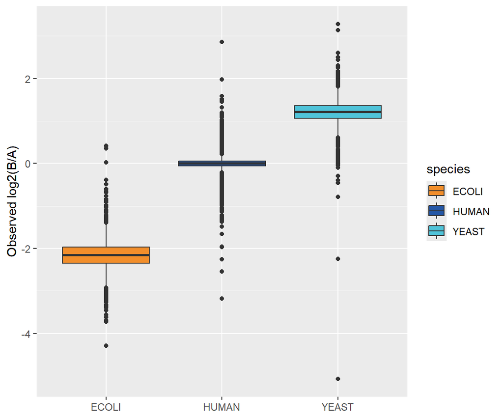

```r
ggplot(df_metrics,
  aes(species, observed_logFC, fill = species)) +
  geom_boxplot() +
  scale_fill_manual(values = cols) +
  labs(x = NULL, y = "Observed log2(B/A)")
```

# Theoretical value + IQR band (25th-75th percentile)

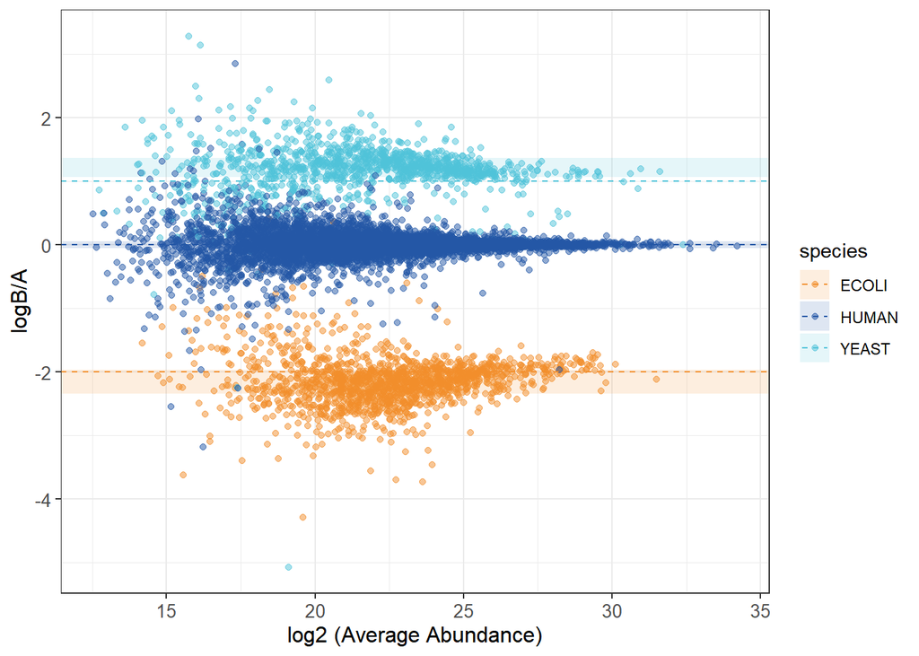

```r
p_fc <- ggplot(df_metrics,
    aes(abundance, observed_logFC, color = species)) +


geom_rect(data = iqr_df,
    aes(xmin = -Inf,
        xmax = Inf,
        ymin = ymin,
        ymax = ymax,
        fill = species),
    inherit.aes = FALSE,
    alpha = 0.15) +
    geom_point(alpha = 0.5) +

    geom_hline(data = sampleComposition,
        aes(yintercept = expected_logFC, color = species), linetype = 2) +
    scale_color_manual(values = cols) +
    scale_fill_manual(values = cols) +

    theme_bw() +
    theme (axis.title = element_text(size = 12), axis.text = element_text(size = 10)) +
    labs(x = "log2 (Average Abundance)", y = "logB/A")

p_fc
```